# Complex Network - Exercises I

## Question 10

```python
def read_csv_and_Gcc(path, source='u', target='v'):
    """
    FUNCTION:
    Read a file gml type that contains node connections
    and their weights as float.

    PARAMETERS:
    path: file path as string located in computer

    RETURN:
    tuple: (pos, G), representing the position object
    (networkx as nx, spring_layout()) for draw purpose and
    the Graph G itself made from file
    """
    import pandas as pd
    df = pd.read_csv(path)
    df.head()

    G = nx.from_pandas_edgelist(df, source=source, target=target)
    G = nx.convert_node_labels_to_integers(G, first_label=0)
    labels = G.nodes()
    pos = nx.spring_layout(G)
    G = G.to_undirected()
    G.remove_edges_from(G.selfloop_edges())
    Gcc = sorted(nx.connected_component_subgraphs(G), key=len, reverse=True)
    G = Gcc[0]
    return pos, G
```

```python
def complexity_measure(G):
    """
    FUNCTION:
    Calculates the complexity measure from a given graph

    PARAMETERS:
    G: Graph object from networkx

    RETURN:
    float: Complexity measure
    """
    hist_x, hist_y = degree_distribution(G, normalized=False)
    count = 0.
    mean = 0.
    for i in hist_y:
        mean+=i
        count+=1
    mean/=count

    var = 0
    count = 0
    for k in hist_y:
        var+=(k-mean)**2
        count+=1
    var/=count

    a = var/mean
    return a
```

```python
import pandas as pd
```

```python
pos, G_washing = read_csv_and_Gcc('/home/jorge/Downloads/12-FL-counties-street_networks-node_edge_lists/12133_Washington_County/edge_list.csv')
```

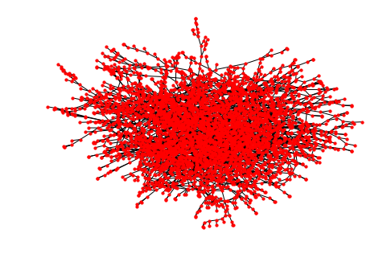

```python
nx.draw(G_washing, with_labels=False, node_color='red', node_size=10, pos=pos)
plt.show()
```

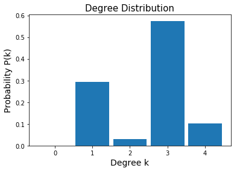

```python
bar_histogram_degree_plot(G_washing, normalized=True)
```

```python
pos, G_stJohn = read_csv_and_Gcc('/home/jorge/Downloads/12-FL-counties-street_networks-node_edge_lists/12109_St._Johns_County/edge_list.csv')
```

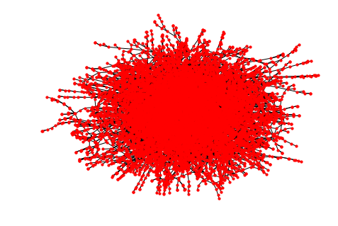

```python
nx.draw(G_stJohn, with_labels=False, node_color='red', node_size=10, pos=pos)
plt.show()
```

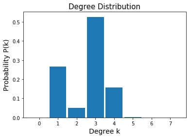

```python
bar_histogram_degree_plot(G_stJohn, normalized=True)
```

```python
pos, G_hawaiiStreet = read_csv_and_Gcc('/home/jorge/Downloads/15-HI-urbanized_areas-street_networks-node_edge_lists/89770_Urban_Honolulu_HI_Urbanized_Area/edge_list.csv')
```

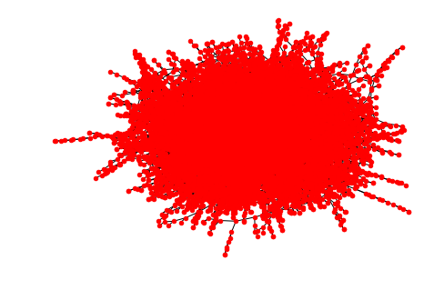

```python
nx.draw(G_hawaiiStreet, with_labels=False, node_color='red', node_size=20, pos=pos)
plt.show()
```

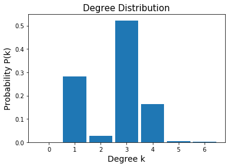

```python
bar_histogram_degree_plot(G_hawaiiStreet, normalized=True)
```

```python
NK = [] #Stores number of nodes
AVG_K = [] #Stores the average degree
COMPLX = [] #Stores complexity measure
AVG_CC = [] #Stores average cluster coefficient
AVG_SP = [] #Stores average shortest pathlength
DIAM = [] #Stores diameter

for i in range(3):
    if i == 0:
        G_i = G_washing
    elif i == 1:
        G_i = G_stJohn
    else:
        G_i = G_hawaiiStreet

    #Number of nodes
    total_nodes = len(list(G_i.nodes()))
    NK.append(total_nodes)

    #Average degree
    k_degree = []
    for node in G_i.degree():
        k_degree.append(node[1])

    norm = sum(k_degree)/len(k_degree)
    AVG_K.append(norm)

    #Complexity measure
    alpha = complexity_measure(G_i)

    COMPLX.append(alpha)

    #Average cluster coefficient
    total_nodes = len(list(G_i.nodes()))
    cluster_coeff = nx.clustering(G_i).values()
    avg_cc = sum(cluster_coeff)/total_nodes
    AVG_CC.append(avg_cc)

    #Average Shortest pathlength
    avg_sp = nx.average_shortest_path_length(G_i)
    AVG_SP.append(avg_sp)

    #Diameter
    diam = nx.diameter(G_i)
    DIAM.append(diam)
```

```python
#NK: Number of nodes AVG_K: average degree COMPLX: complexity measure, AVG_CC: average cluster coefficient
#AVG_SP: average shortest pathlength DIAMT: Diameter

import pandas as pd
df = pd.DataFrame({'K':NK,'AVG_K':AVG_K,'COMPLX':COMPLX,'AVG_CC':AVG_CC,'AVG_SP':AVG_SP,'DIAM':DIAM})
print(df)
```

```
       K     AVG_K       COMPLX    AVG_CC     AVG_SP  DIAM
0   4083  2.481509   931.555033  0.037309  41.617736   106
1  10938  2.581642  2727.138005  0.048951  61.092946   150
2  12993  2.580466  3079.708524  0.038900  48.178778   156
```

The differences occur strongly on average shortest path (AVG_SP) and complexity measure (COMPLX) quantities. The last one with the higher distinction. Those measures show us that, even though thoses graphs have relatively the same connections, the average proximity between two nodes is greater on Washington streets' map than on Saint John's, make the former not necessarily easier to navigate, but instead, quicker to find arrive to our desired destination. On the other hand, we can conclude that Washington, Sant John and Hawaii street's map have increasing complexity, on this order. Once we understand that complexity measure is related to the ratio between variance and mean value from degree distribution, and since those distributions have near the same average degree, it is possible to assure that Hawaii streets' map have greater variance (degree distribution is more spread) than those other maps. In practical terms, it means Hawaii is more difficult to navigate than Saint John, which is more difficult than Washington, once the average number of possible bifurcations at some street on Washington is, on average, lesser than Hawaii. This comprehension can be made also considering the degree probability distribution showed on the last three graphic plots, showed above.